# Milestone Report

Brandon Clark

6/26/2020

# Coursera Data Science Milestone Report

## Introduction

Below is the milestone report for the Coursera Data Science Specialization capstone project. We were given 3 text files containing collected text from Blogs, Twitter posts, and News articles. I will be using these datasets to create a predictive text model to provide text input recommendations on mobile devices.

## Assumptions

Data is downloaded and unzipped in active R directory

## Load Packages and Data

```r
library(tm)
library(dplyr)
```

```r
library(wordcloud)
library(textreg)
library(quanteda)
blogsFile <- file( paste0( curDir, '/datasets/en_US/en_US.blogs.txt' ), open = "rb")
en_US.blogs = readLines( blogsFile, encoding = "UTF-8", skipNul=TRUE )

twitterFile <- file( paste0( curDir, '/datasets/en_US/en_US.twitter.txt' ), open = "rb" )
en_US.twitter = readLines( twitterFile, encoding = "UTF-8", skipNul=TRUE )

newsFile <- file( paste0( curDir, '/datasets/en_US/en_US.news.txt' ), open = "rb")
en_US.news = readLines( newsFile, encoding = "UTF-8", skipNul=TRUE)

#remove non eneglish characters
en_US.blogs <- iconv(en_US.blogs, "latin1", "ASCII", sub="")
en_US.twitter<- iconv(en_US.twitter, "latin1", "ASCII", sub="")
en_US.news <- iconv(en_US.news, "latin1", "ASCII", sub="")
```

## Get Word and Line Counts

We will use a helper function to get word and line counts

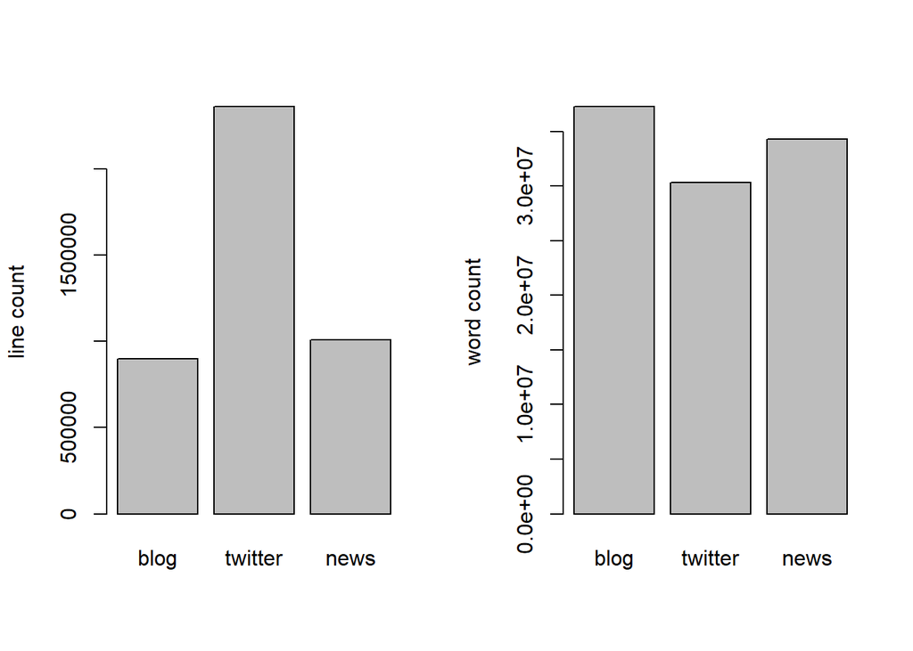

```r
f.word.count <- function(my.list) { sum(stringr::str_count(my.list, "\\S+")) }
list <- list(blog = en_US.blogs , twitter = en_US.twitter, news = en_US.news)

df <- data.frame(source = c("blog", "twitter", "news"), line.count = NA, word.count = NA)

df$line.count <- sapply(list, length)
df$word.count <- sapply(list, f.word.count)

par(mfrow=c(1,2))
barplot(height = df$line.count, names.arg = df$source , ylab = 'line count')
barplot(height = df$word.count, names.arg = df$source , ylab = 'word count')
```

## Sample Data

```r
percent <- 0.05

sampleFunction <- function(data, percent)
{
  return(data[as.logical(rbinom(length(data),2,percent))])
}

en_US.blogs   <- sampleFunction(en_US.blogs, percent)
en_US.twitter   <- sampleFunction(en_US.twitter, percent)
en_US.news   <- sampleFunction(en_US.news, percent)

allSources<-c(en_US.blogs,en_US.twitter,en_US.news)
```

## Convert to Corpus and Clean

Each datasource will need to be converted into a corpus. We will then clean each corpus by removing punctuation, numbers, converting to all lower case, removing stop words, and stripping white space.

NOTE: Stop words are removed for exploratory analysis. They will be an important part of the final alogithm and will be included later.

We will also create dataframes to store word frequency.

```r
en_US.blogsCorp <- Corpus(VectorSource(en_US.blogs))
en_US.twitterCorp <- Corpus(VectorSource(en_US.twitter))
en_US.newsCorp <- Corpus(VectorSource(en_US.news))
allSourcesCorp <- Corpus(VectorSource(allSources))

allSourcesCorpCleaned <- allSourcesCorp
allSourcesCorpCleaned <- tm_map(allSourcesCorpCleaned, removePunctuation)
allSourcesCorpCleaned <- tm_map(allSourcesCorpCleaned, removeNumbers)
allSourcesCorpCleaned <- tm_map(allSourcesCorpCleaned, tolower)
allSourcesCorpCleaned <- tm_map(allSourcesCorpCleaned, removeWords, stopwords("english"))
allSourcesCorpCleaned <- tm_map(allSourcesCorpCleaned, stripWhitespace)

allSourcesDfm <- dfm(corpus(allSourcesCorpCleaned), verbose = FALSE)
allSourcesD <- textstat_frequency(allSourcesDfm)
colnames(allSourcesD) <- c('word','allSourcesFreq','allSourcesrank')
allSourcesD<-allSourcesD[,1:3]

en_US.blogsCleaned <- en_US.blogsCorp
en_US.blogsCleaned <- tm_map(en_US.blogsCleaned, removePunctuation)
en_US.blogsCleaned <- tm_map(en_US.blogsCleaned, removeNumbers)
en_US.blogsCleaned <- tm_map(en_US.blogsCleaned, tolower)
en_US.blogsCleaned <- tm_map(en_US.blogsCleaned, removeWords, stopwords("english"))
en_US.blogsCleaned <- tm_map(en_US.blogsCleaned, stripWhitespace)

blogsDfm <- dfm(corpus(en_US.blogsCleaned), verbose = FALSE)
blogsD <- textstat_frequency(blogsDfm)
colnames(blogsD) <- c('word','blogsFreq','blogsRank')
blogsD<-blogsD[,1:3]

en_US.twitterCleaned <- en_US.twitterCorp
en_US.twitterCleaned <- tm_map(en_US.twitterCleaned, removePunctuation)
en_US.twitterCleaned <- tm_map(en_US.twitterCleaned, removeNumbers)
en_US.twitterCleaned <- tm_map(en_US.twitterCleaned, tolower)
en_US.twitterCleaned <- tm_map(en_US.twitterCleaned, removeWords, stopwords("english"))
en_US.twitterCleaned <- tm_map(en_US.twitterCleaned, stripWhitespace)

twitterDfm <- dfm(corpus(en_US.twitterCleaned), verbose = FALSE)
twitterD <- textstat_frequency(twitterDfm)
colnames(twitterD) <- c('word','twitterFreq','twitterRank')
twitterD<-twitterD[,1:3]

en_US.newsCleaned <- en_US.newsCorp
en_US.newsCleaned <- tm_map(en_US.newsCleaned, removePunctuation)
en_US.newsCleaned <- tm_map(en_US.newsCleaned, removeNumbers)
en_US.newsCleaned <- tm_map(en_US.newsCleaned, tolower)
en_US.newsCleaned <- tm_map(en_US.newsCleaned, removeWords, stopwords("english"))
en_US.newsCleaned <- tm_map(en_US.newsCleaned, stripWhitespace)

newsDfm <- dfm(corpus(en_US.newsCleaned), verbose = FALSE)
newsD <- textstat_frequency(newsDfm)
colnames(newsD) <- c('word','newsFreq','newsRank')
newsD<-newsD[,1:3]

allSourcesDF <- allSourcesD
allSourcesDF <- left_join(allSourcesD, blogsD, by = 'word')
allSourcesDF <- left_join(allSourcesDF, newsD, by = 'word')
allSourcesDF <- left_join(allSourcesDF, twitterD, by = 'word')
head(allSourcesDF, n = 20)
```

```
##      word allSourcesFreq allSourcesrank blogsFreq blogsRank newsFreq newsRank
## 1    said          29919              1      3607        38    24547        1
## 2    just          29616              2      9822         2     5223        8
## 3     one          27899              3     12048         1     8015        2
## 4    like          26049              4      9518         4     4746       15
## 5      im          24265              5      6856         7     1992       66
## 6     can          24034              6      9717         3     5645        6
## 7     get          21953              7      6871         6     4191       17
## 8    time          20671              8      8447         5     4979       11
## 9     new          18918              9      5235        13     6847        3
## 10   good          17423             10      4701        24     2902       34
## 11    now          17384             11      5853         9     3601       19
## 12   dont          17163             12      5551        11     2954       31
## 13    day          16891             13      5038        15     2915       33
## 14   know          16015             14      6000         8     2291       52
```

[output cut: 27 more lines]

## Wordcloud

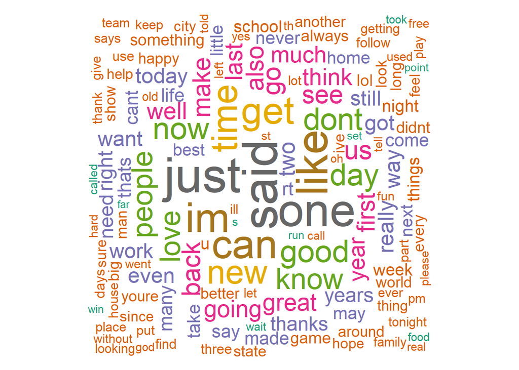

```r
par(mfrow=c(1,1))
set.seed(1234)

wordcloud(words = allSourcesDF$word, freq = allSourcesDF$allSourcesFreq, min.freq = 1,
          max.words=200, random.order=FALSE, rot.per=0.35,
          colors=brewer.pal(8, "Dark2"), main = 'All Data Sources')
```

## Plot Cumulative Word Frequency

The below plot shows that the majority of the words are in the most frequent and that there is a long tail of less frequently used words. There are over 200000 words. The top 1000 (removing stop words) make up 50% of the total word count! The top 17000 make up 90%.

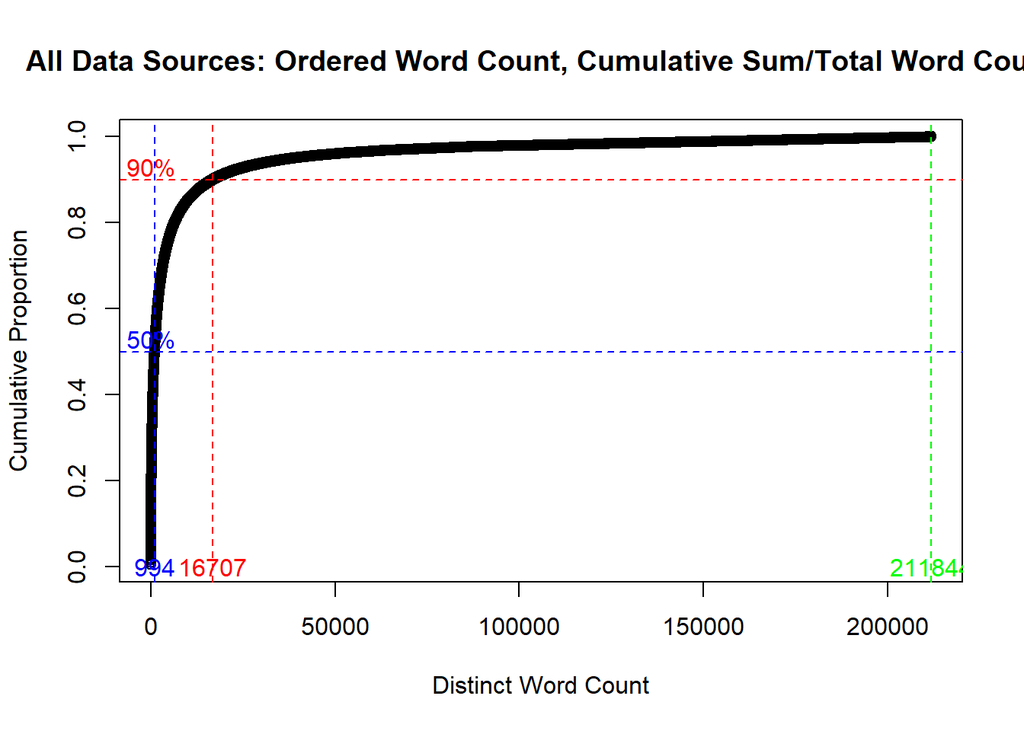

```r
allSourcesDF$cumProportion <- cumsum( allSourcesDF$allSourcesFreq )/sum(allSourcesDF$allSourcesFreq )

par(mfrow=c(1,1))
plot1 <-plot( seq.int(nrow(allSourcesDF)) , cumsum( allSourcesDF$allSourcesFreq )/sum(allSourcesDF$allSourcesFreq ),
      xlab = "Distinct Word Count", ylab = "Cumulative Proportion",
      main = "All Data Sources: Ordered Word Count, Cumulative Sum/Total Word Count") +
  abline(h = .9, col = "red", lty = 2, cex =  2) +
  abline(h = .5, col = "blue", lty = 2, cex = 2) +
  abline(v=nrow(allSourcesDF) , col = "green", lty = 2, cex = 2) +
  abline(v = nrow(allSourcesDF[which(allSourcesDF$cumProportion < .5),]), col = "blue", lty = 2, cex = 2) +
  abline(v = nrow(allSourcesDF[which(allSourcesDF$cumProportion < .9),]), col = "red", lty = 2, cex = 2) +
  text(x=0,y=.53, "50%", col = "blue", cex = 1) +
  text(x=0,y=.93, "90%", col = "red", cex = 1) +
  text(x=nrow(allSourcesDF[which(allSourcesDF$cumProportion < .9),]),y=0, nrow(allSourcesDF[which(allSourcesDF$cumProportion < .9),]), col = "red", cex = 1) +
  text(x=nrow(allSourcesDF[which(allSourcesDF$cumProportion < .5),]),y=0, nrow(allSourcesDF[which(allSourcesDF$cumProportion < .5),]), col = "blue", cex = 1) +
  text(x=nrow(allSourcesDF),y=0, nrow(allSourcesDF), col = "green", cex = 1)
```

```r
plot1
```

```
## integer(0)
```

## Unigrams, Bigrams, Trigrams

N-grams will be an important part of the prediction alogithm. We will look at words commonly occuring together

We will use the publicly shared ngram_tokenizer function to assist: https://github.com/zero323/r-snippets/blob/master/R/ngram_tokenizer.R

Unigrams

```r
unigram.tokenizer <- ngram_tokenizer(1)
wordlist <- unigram.tokenizer(as.character(allSourcesCorpCleaned))
unigram.df <- data.frame(V1 = as.vector(names(table(unlist(wordlist)))), V2 = as.numeric(table(unlist(wordlist))))
names(unigram.df) <- c("word","freq")
row.names(unigram.df) <- NULL
unigram.df <- unigram.df[with(unigram.df, order(-unigram.df$freq)),]
head(unigram.df, n=10)
```

```
##        word  freq
## 158468 said 29919
## 95413  just 29616
## 131055  one 27899
## 104689 like 26049
## 87457    im 24265
## 27030   can 24034
## 71132   get 21953
## 186391 time 20671
## 124705  new 18918
## 73368  good 17423
```

Bigrams

```r
bigram.tokenizer <- ngram_tokenizer(2)
wordlist <- bigram.tokenizer(as.character(allSourcesCorpCleaned))
bigram.df <- data.frame(V1 = as.vector(names(table(unlist(wordlist)))), V2 = as.numeric(table(unlist(wordlist))))
names(bigram.df) <- c("word","freq")
row.names(unigram.df) <- NULL
bigram.df <- bigram.df[with(bigram.df, order(-bigram.df$freq)),]
head(bigram.df)
```

```
##               word freq
## 2563163  right now 2431
## 850297   dont know 1938
## 2042396   new york 1917
## 1665103  last year 1880
## 435261   cant wait 1821
## 1664409 last night 1496
```

Trigrams

```r
trigram.tokenizer <- ngram_tokenizer(3)
wordlist <- trigram.tokenizer(as.character(allSourcesCorpCleaned))
trigram.df <- data.frame(V1 = as.vector(names(table(unlist(wordlist)))), V2 = as.numeric(table(unlist(wordlist))))
names(trigram.df) <- c("word","freq")
row.names(trigram.df) <- NULL
trigram.df <- trigram.df[with(trigram.df, order(-trigram.df$freq)),]
head(trigram.df)
```

```
##                      word freq
## 1954739 happy mothers day  344
## 627717      cant wait see  342
## 2512186       let us know  262
## 3055203     new york city  222
## 1954814    happy new year  204
## 2157011    im pretty sure  179
```

## Next Steps

N-grams will be a main piece of the prediction alogithm. The last word (unigram) of an N-gram will split from the previous ones. The most likely unigrams will be recommended. - Bigrams will be separated into unigram/unigram - Trigram will be separated into bigram/unigram - This will continue until the largest N is reached

We will also look into models that weight different various datasources based on their predictive performance.

The final model will be in a Shiny App